# Useful Things to do with R’s **Inf** Keyword

Having used R for some years now, I’ve come across a few instances where R’s **Inf** keyword can be used to yield a practical outcome. For those unfamiliar with R’s **Inf** keyword, it is defined as a postive or negative number divided by zero yielding postive or negative **Inf**, respectively.

```r
c(plus_inf = 1/0, minus_inf = -1/0)
```

```
##  plus_inf minus_inf
##       Inf      -Inf
```

So how we can make practical use of infinity in R? Here are a few applications I’ve found:

1. *cut()* defining the upper and lower extremes.
2. *ggplot2::annotate()* positioning text in ggplot at a corner or edge.
3. *integrate()* when setting the upper and lower integral bounds

# **Inf** with *cut()*

Suppose you want to bin the following set of numbers into five discrete levels.

```
{-100, -1,1,1,1,2,2,2,5,5,5,10,10,10,100,1000}
```

You might do something like,

```r
numbers <- c(-100, -1,1,1,1,2,2,2,5,5,5,10,10,10,100,1000)
bins <- cut(numbers, breaks = c(-101,-2,2,5,11, 1001))
xtabs(~bins)
```

```
## bins
##  (-101,-2]     (-2,2]      (2,5]     (5,11] (11,1e+03]
##          1          7          3          3          2
```

The above code explicitly shows how we might bin the data including the extreme values -100,100, and 1000. But with real data, extrama can change when new data is added. For example, what if we received the following new pieces of data: -102 and 1002? Below, we’ve added them to our list and re-binned them as before.

```r
numbers <- c(-102, -100, -1,1,1,1,2,2,2,5,5,5,10,10,10,100,1000,1002)
bins <- cut(numbers, breaks = c(-101,-2,2,5,11, 1001))
xtabs(~bins)
```

```
## bins
##  (-101,-2]     (-2,2]      (2,5]     (5,11] (11,1e+03]
##          1          7          3          3          2
```

Opps! The new data was not included in the binning. We would need to manually expand our limits manually, or we could perhaps do something clever with the *max* and *min* functions.

Alternativly, we can solve this problem with R’s $\pm$ **Inf** keyword by placing $\pm$ **Inf** in the *breaks* argument of the *cut* function (*see line 2 below*)

```r
numbers <- c(-102, -100, -1,1,1,1,2,2,2,5,5,5,10,10,10,100,1000,1002)
bins <- cut(numbers, breaks = c(-Inf,-2,2,5,11, Inf))
xtabs(~bins)
```

```
## bins
## (-Inf,-2]    (-2,2]     (2,5]    (5,11] (11, Inf]
##         2         7         3         3         3
```

Now, when new data is collected that is less than -2 or greater than 11 there will be a bin to catch it, no mater how big or how small.

# **Inf** in integrate()

Integration is never fun, but sometimes its necessary. For example to get the probability of a normally distributed event between two limits you would need to integration the normal distribution funciton shown below.

$$f(x |\mu, \sigma^2) = \frac{1}{\sqrt{2\pi\sigma^2}} e^{-\frac{x - \mu}^2{2\sigma^2}}$$

```r
dn <- function(x){dnorm(x = x, mean = 0, sd = 1)}
integrate(dn, -Inf,  c(0.5))
```

```
## 0.6914625 with absolute error < 1.6e-09
```

# **Inf** in ggplot2::annotate() - text positioning

In the documentation for ggplot2 http://docs.ggplot2.org/current/geom_text.html you are told you can position text in a plot in the following way.

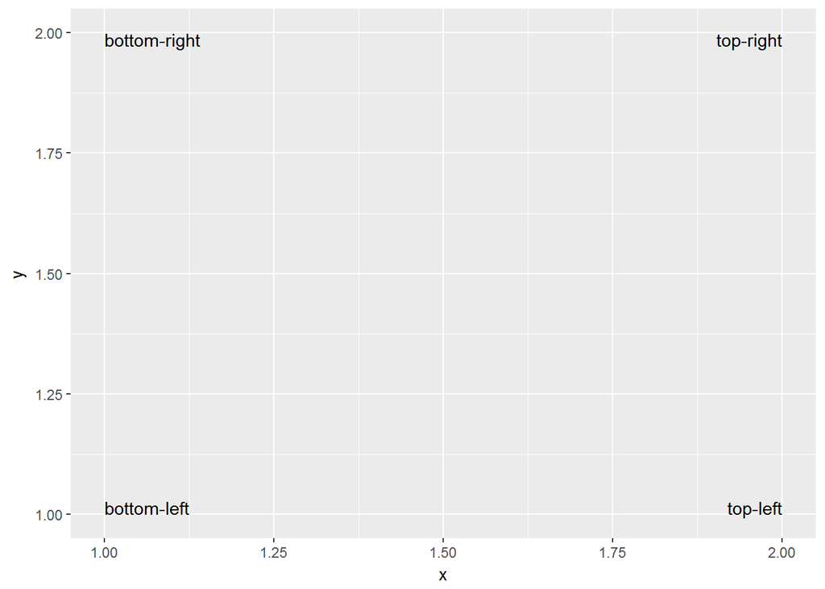

```r
df <- data.frame(
  x = c(1, 1, 2, 2),
  y = c(1, 2, 1, 2),
  text = c("bottom-left", "bottom-right", "top-left", "top-right")
)

ggplot(df, aes(x, y)) + geom_text(aes(label = text), vjust = "inward", hjust = "inward")
```

Ok, this puts the text in the corners, but look what happens when we change the plot limits with *ylim()* and *xlim()*.

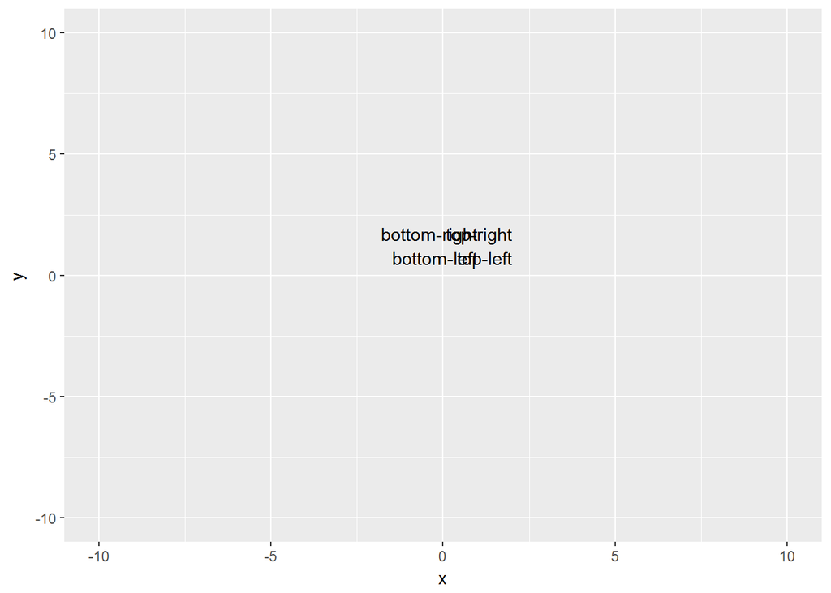

```r
ggplot(df, aes(x, y)) + geom_text(aes(label = text), vjust = "inward", hjust = "inward") +
  ylim(-10,10) + xlim(-10,10)
```

Oops. The text is no longer in the corners. Using R’s **Inf** keyword, we can achor the text in a simple, robust way to the corners and edges of a plot. Here is the plot again with original limits above using **Inf**. I’ve also placed some extra annotations in the middle of each side for demonstration.

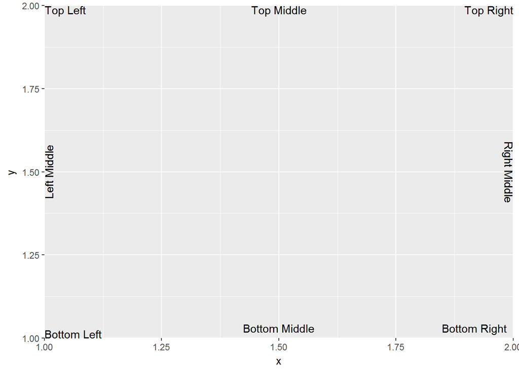

```r
gg_corner_edge_text <- ggplot(df, aes(x,y)) +
  annotate("text", label="Top Left",  x = -Inf, y=Inf, hjust=0, vjust=1) +
  annotate("text", label="Bottom Left",  x = -Inf, y=-Inf, hjust=0, vjust=0) +
  annotate("text", label="Top Right",  x = Inf, y=Inf, hjust=1, vjust=1) +
   annotate("text", label="Bottom Right",  x = Inf, y=-Inf, hjust=1.1, vjust=-.7) +

  #### Placeing text at Top or Bottom Givben X
  annotate("text", label="Top Middle",  x=(max(df$x)+min(df$x))/2 , y=Inf, hjust=.5, vjust=1) +
  annotate("text", label="Bottom Middle",  x=(max(df$x)+min(df$x))/2 , y=-Inf, hjust=.5, vjust=-.7) +

  #### Placeing text at Left or Right Side Given Y
  annotate("text", label="Right Middle", x=Inf , y=(max(df$y)+min(df$y))/2, hjust=.5, vjust=1, angle=-90) +
  annotate("text", label="Left Middle",  x=-Inf , y=(max(df$y)+min(df$y))/2, hjust=.5, vjust=1, angle=90)

gg_corner_edge_text
```

Here is the same plot, except now we’ve expanded the limits with *xlim()* and *ylim()* as above to show that the text stays on the edges.

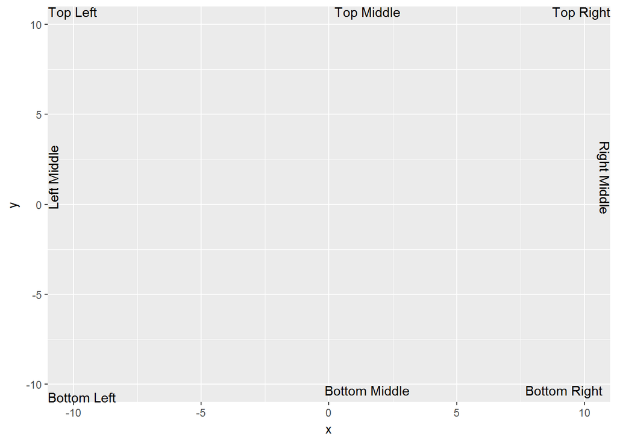

```r
gg_corner_edge_text + ylim(-10,10) + xlim(-10,10)
```

Awesome! The text stayed in the corners, and center edge of each side. However, it is no longer centered correctly. At this point, I do not have a robust way to deal with centering, but the text is locked to the edges of the plot because of the **Inf** keyword. Fine adjustment to the alignment can be achieved with hjust and vjust agruments.

# Summary

In this brief post, we shown how to use R’s **Inf** keyword to bin data using the *cut()* function and position text at the corners and edges of plots made with ggplot.